# MACHINE LEARNING

### Analizamos nuestro dataset y sus variables.

```python
crisis.info()
```

```
<class 'pandas.core.frame.DataFrame'>
RangeIndex: 1059 entries, 0 to 1058
Data columns (total 14 columns):
case                               1059 non-null int64
cc3                                1059 non-null object
country                            1059 non-null object
year                               1059 non-null int64
systemic_crisis                    1059 non-null int64
exch_usd                           1059 non-null float64
domestic_debt_in_default           1059 non-null int64
sovereign_external_debt_default    1059 non-null int64
gdp_weighted_default               1059 non-null float64
inflation_annual_cpi               1059 non-null float64
independence                       1059 non-null int64
currency_crises                    1059 non-null int64
inflation_crises                   1059 non-null int64
banking_crisis                     1059 non-null object
dtypes: float64(3), int64(8), object(3)
memory usage: 115.9+ KB
```

Como podemos observar, las variables: "cc3", "case", y "year resultan redundantes en el estudio no aportan información relevante.Las dos primeras junto a "banking_crisis" son categóricas y en "gdp_weighted_default" solo observamos 0 por lo que procedemos a eliminarla de la misma forma.

```python
crisis_2=crisis.drop(['banking_crisis','cc3','case','gdp_weighted_default','year'],axis=1)
crisis_2
```

|  | country | systemic_crisis | exch_usd | domestic_debt_in_default | sovereign_external_debt_default | inflation_annual_cpi | independence | currency_crises | inflation_crises |
| --- | --- | --- | --- | --- | --- | --- | --- | --- | --- |
| 0 | Algeria | 1 | 5.226400e-02 | 0 | 0 | 3.441456e+00 | 0 | 0 | 0 |
| 1 | Algeria | 0 | 5.279800e-02 | 0 | 0 | 1.414914e+01 | 0 | 0 | 0 |
| 2 | Algeria | 0 | 5.227400e-02 | 0 | 0 | -3.718593e+00 | 0 | 0 | 0 |
| 3 | Algeria | 0 | 5.168000e-02 | 0 | 0 | 1.120390e+01 | 0 | 0 | 0 |
| 4 | Algeria | 0 | 5.130800e-02 | 0 | 0 | -3.848561e+00 | 0 | 0 | 0 |
| 5 | Algeria | 0 | 5.154600e-02 | 0 | 0 | -2.092418e+01 | 0 | 0 | 0 |
| 6 | Algeria | 0 | 5.186700e-02 | 0 | 0 | -1.769547e+00 | 0 | 0 | 0 |
| 7 | Algeria | 0 | 5.186700e-02 | 0 | 0 | 2.911605e+01 | 0 | 0 | 1 |
| 8 | Algeria | 0 | 5.194800e-02 | 0 | 0 | -1.492537e+00 | 0 | 0 | 0 |
| 9 | Algeria | 0 | 5.202900e-02 | 0 | 0 | -1.683136e+01 | 0 | 0 | 0 |
| 10 | Algeria | 0 | 5.235600e-02 | 0 | 0 | 3.881188e+00 | 0 | 0 | 0 |
| 11 | Algeria | 0 | 5.202900e-02 | 0 | 0 | 1.261914e+01 | 0 | 0 | 0 |
| 12 | Algeria | 0 | 5.076100e-02 | 0 | 0 | -1.235613e+01 | 0 | 0 | 0 |
| 13 | Algeria | 0 | 5.200200e-02 | 0 | 0 | -1.390498e+00 | 0 | 0 | 0 |
| 14 | Algeria | 0 | 5.216500e-02 | 0 | 0 | -1.594203e+01 | 0 | 0 | 0 |
| 15 | Algeria | 0 | 4.490300e-01 | 0 | 0 | 9.756098e+00 | 0 | 0 | 0 |
| 16 | Algeria | 0 | 4.918900e-01 | 0 | 0 | 2.222222e+01 | 0 | 0 | 1 |
| 17 | Algeria | 0 | 4.493700e-01 | 0 | 0 | 1.636364e+01 | 0 | 0 | 0 |
| 18 | Algeria | 0 | 7.500000e-01 | 0 | 0 | 2.812500e+01 | 0 | 0 | 1 |
| 19 | Algeria | 0 | 5.000000e-01 | 0 | 0 | 4.634146e+01 | 0 | 1 | 1 |
| 20 | Algeria | 0 | 5.000000e-01 | 0 | 0 | 4.166667e+01 | 0 | 1 | 1 |
| 21 | Algeria | 0 | 1.191000e+00 | 0 | 0 | 2.941176e+01 | 0 | 0 | 1 |
| 22 | Algeria | 0 | 1.191000e+00 | 0 | 0 | 1.818182e+01 | 0 | 0 | 0 |
| 23 | Algeria | 0 | 1.193000e+00 | 0 | 0 | 6.923077e+01 | 0 | 0 | 1 |
| 24 | Algeria | 0 | 2.662000e+00 | 0 | 0 | 6.363636e+01 | 0 | 0 | 1 |
| 25 | Algeria | 0 | 3.490000e+00 | 0 | 0 | 2.361111e+01 | 0 | 0 | 1 |
| 26 | Algeria | 0 | 3.499000e+00 | 0 | 0 | 0.000000e+00 | 0 | 0 | 0 |
| 27 | Algeria | 0 | 3.500000e+00 | 0 | 0 | 6.741573e+00 | 0 | 0 | 0 |
| 28 | Algeria | 0 | 3.500000e+00 | 0 | 0 | 6.315789e+00 | 0 | 0 | 0 |
| 29 | Algeria | 0 | 3.500000e+00 | 0 | 0 | -9.900990e-01 | 0 | 0 | 0 |
| ... | ... | ... | ... | ... | ... | ... | ... | ... | ... |
| 1029 | Zimbabwe | 0 | 1.450000e-26 | 0 | 0 | 2.030000e+01 | 1 | 1 | 1 |
| 1030 | Zimbabwe | 0 | 1.630000e-26 | 0 | 0 | 8.300000e+00 | 1 | 0 | 0 |
| 1031 | Zimbabwe | 0 | 1.680000e-26 | 0 | 0 | 1.450000e+01 | 1 | 0 | 0 |
| 1032 | Zimbabwe | 0 | 1.600000e-26 | 0 | 0 | 1.250000e+01 | 1 | 0 | 0 |
| 1033 | Zimbabwe | 0 | 1.930000e-26 | 0 | 0 | 7.400000e+00 | 1 | 1 | 0 |
| 1034 | Zimbabwe | 0 | 2.220000e-26 | 0 | 0 | 1.280000e+01 | 1 | 1 | 0 |
| 1035 | Zimbabwe | 0 | 2.610000e-26 | 0 | 0 | 1.740000e+01 | 1 | 1 | 0 |
| 1036 | Zimbabwe | 0 | 5.040000e-26 | 0 | 0 | 2.400000e+01 | 1 | 1 | 1 |
| 1037 | Zimbabwe | 0 | 5.370000e-26 | 0 | 0 | 4.160000e+01 | 1 | 0 | 1 |
| 1038 | Zimbabwe | 0 | 6.810000e-26 | 0 | 0 | 2.820000e+01 | 1 | 1 | 1 |
| 1039 | Zimbabwe | 0 | 8.380000e-26 | 0 | 0 | 2.111354e+01 | 1 | 1 | 1 |
| 1040 | Zimbabwe | 1 | 9.310000e-26 | 0 | 0 | 2.580874e+01 | 1 | 0 | 1 |
| 1041 | Zimbabwe | 1 | 1.080000e-25 | 0 | 0 | 1.640028e+01 | 1 | 1 | 0 |
| 1042 | Zimbabwe | 1 | 1.830000e-25 | 0 | 0 | 2.006504e+01 | 1 | 1 | 1 |
| 1043 | Zimbabwe | 1 | 3.710000e-25 | 0 | 0 | 4.661127e+01 | 1 | 1 | 1 |
| 1044 | Zimbabwe | 1 | 3.720000e-25 | 0 | 0 | 5.692320e+01 | 1 | 0 | 1 |
| 1045 | Zimbabwe | 1 | 5.500000e-25 | 1 | 1 | 5.520370e+01 | 1 | 1 | 1 |
| 1046 | Zimbabwe | 1 | 5.510000e-25 | 1 | 1 | 1.121184e+02 | 1 | 0 | 1 |
| 1047 | Zimbabwe | 1 | 5.500000e-25 | 1 | 1 | 1.989286e+02 | 1 | 0 | 1 |
| 1048 | Zimbabwe | 1 | 7.950000e-24 | 1 | 1 | 5.987448e+02 | 1 | 1 | 1 |
| 1049 | Zimbabwe | 1 | 5.600000e-23 | 1 | 1 | 1.327468e+02 | 1 | 1 | 1 |
| 1050 | Zimbabwe | 1 | 8.460000e-22 | 1 | 1 | 5.858444e+02 | 1 | 1 | 1 |
| 1051 | Zimbabwe | 1 | 3.000000e-19 | 1 | 1 | 1.281114e+03 | 1 | 1 | 1 |
| 1052 | Zimbabwe | 1 | 1.900000e-16 | 1 | 1 | 6.627989e+04 | 1 | 1 | 1 |
| 1053 | Zimbabwe | 1 | 2.000000e-03 | 1 | 1 | 2.198970e+07 | 1 | 1 | 1 |
| 1054 | Zimbabwe | 1 | 3.548000e+02 | 1 | 1 | -7.670000e+00 | 1 | 1 | 0 |
| 1055 | Zimbabwe | 0 | 3.782000e+02 | 1 | 1 | 3.217000e+00 | 1 | 0 | 0 |
| 1056 | Zimbabwe | 0 | 3.619000e+02 | 1 | 1 | 4.920000e+00 | 1 | 0 | 0 |
| 1057 | Zimbabwe | 0 | 3.619000e+02 | 1 | 1 | 3.720000e+00 | 1 | 0 | 0 |
| 1058 | Zimbabwe | 0 | 3.619000e+02 | 1 | 1 | 1.632000e+00 | 1 | 0 | 0 |

1059 rows × 9 columns

```python
crisis_2.tail(10) #mostramos las últimas 10 filas
```

|  | country | systemic_crisis | exch_usd | domestic_debt_in_default | sovereign_external_debt_default | inflation_annual_cpi | independence | currency_crises | inflation_crises |
| --- | --- | --- | --- | --- | --- | --- | --- | --- | --- |
| 1049 | Zimbabwe | 1 | 5.600000e-23 | 1 | 1 | 1.327468e+02 | 1 | 1 | 1 |
| 1050 | Zimbabwe | 1 | 8.460000e-22 | 1 | 1 | 5.858444e+02 | 1 | 1 | 1 |
| 1051 | Zimbabwe | 1 | 3.000000e-19 | 1 | 1 | 1.281114e+03 | 1 | 1 | 1 |
| 1052 | Zimbabwe | 1 | 1.900000e-16 | 1 | 1 | 6.627989e+04 | 1 | 1 | 1 |
| 1053 | Zimbabwe | 1 | 2.000000e-03 | 1 | 1 | 2.198970e+07 | 1 | 1 | 1 |
| 1054 | Zimbabwe | 1 | 3.548000e+02 | 1 | 1 | -7.670000e+00 | 1 | 1 | 0 |
| 1055 | Zimbabwe | 0 | 3.782000e+02 | 1 | 1 | 3.217000e+00 | 1 | 0 | 0 |
| 1056 | Zimbabwe | 0 | 3.619000e+02 | 1 | 1 | 4.920000e+00 | 1 | 0 | 0 |
| 1057 | Zimbabwe | 0 | 3.619000e+02 | 1 | 1 | 3.720000e+00 | 1 | 0 | 0 |
| 1058 | Zimbabwe | 0 | 3.619000e+02 | 1 | 1 | 1.632000e+00 | 1 | 0 | 0 |

### Resumen de los datos

Mediante el siguiente resumen se mostrarán cuales son las principales medidas de dispersión de cada variable.

```python
crisis_2.describe()
```

|  | systemic_crisis | exch_usd | domestic_debt_in_default | sovereign_external_debt_default | inflation_annual_cpi | independence | currency_crises | inflation_crises |
| --- | --- | --- | --- | --- | --- | --- | --- | --- |
| count | 1059.000000 | 1059.000000 | 1059.000000 | 1059.000000 | 1.059000e+03 | 1059.000000 | 1059.000000 | 1059.000000 |
| mean | 0.077432 | 43.140831 | 0.039660 | 0.152975 | 2.084889e+04 | 0.776204 | 0.132200 | 0.129367 |
| std | 0.267401 | 111.475380 | 0.195251 | 0.360133 | 6.757274e+05 | 0.416984 | 0.349847 | 0.335765 |
| min | 0.000000 | 0.000000 | 0.000000 | 0.000000 | -2.850214e+01 | 0.000000 | 0.000000 | 0.000000 |
| 25% | 0.000000 | 0.195350 | 0.000000 | 0.000000 | 2.086162e+00 | 1.000000 | 0.000000 | 0.000000 |
| 50% | 0.000000 | 0.868400 | 0.000000 | 0.000000 | 5.762330e+00 | 1.000000 | 0.000000 | 0.000000 |
| 75% | 0.000000 | 8.462750 | 0.000000 | 0.000000 | 1.164405e+01 | 1.000000 | 0.000000 | 0.000000 |
| max | 1.000000 | 744.306139 | 1.000000 | 1.000000 | 2.198970e+07 | 1.000000 | 2.000000 | 1.000000 |

## 2. Visualización de los datos

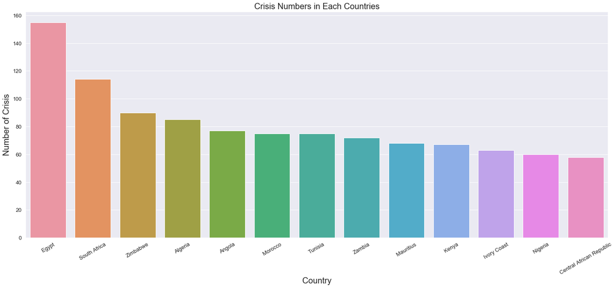

```python
# Plotting a bar graph of the crisis number in each country
# in the column 'country'
country_count  = crisis_2['country'].value_counts()
country_count = country_count[:15,]
plt.figure(figsize=(25,10))
sns.barplot(country_count.index, country_count.values, alpha=1)
plt.xticks(rotation= 30,fontsize=13)
plt.yticks(rotation= 0,fontsize=13)
plt.title('Crisis Numbers in Each Countries',fontsize=20)
plt.ylabel('Number of Crisis', fontsize=20)
plt.xlabel('Country', fontsize=20)
plt.show()
```

A continuación representaremos la deuda de casda país.

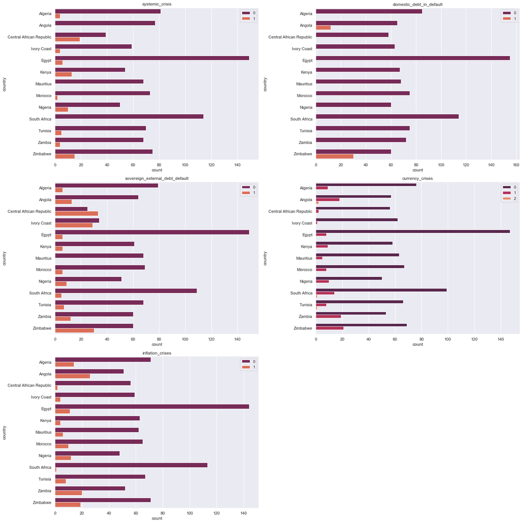

```python
sns.set(style='darkgrid')
cols=['systemic_crisis','domestic_debt_in_default','sovereign_external_debt_default','currency_crises','inflation_crises']
plt.figure(figsize=(20,20))
count=1
for col in cols:
    plt.subplot(3,2,count)
    count+=1
    sns.countplot(y=crisis_2.country,hue=crisis_2[col],palette='rocket')
    plt.legend(loc=0)
    plt.title(col)
plt.tight_layout()
plt.show()
```

Realizamos una matriz de correlaciones para ver como se relacionan y la representamos gráficamente

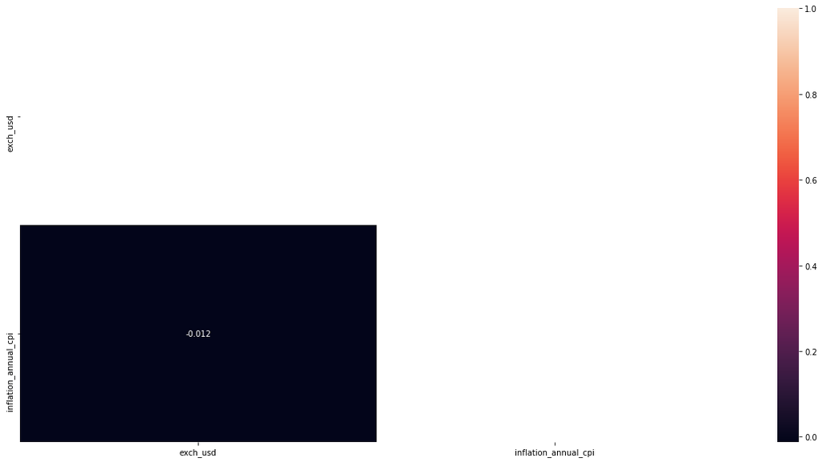

```python
crisis_nuevo = crisis_2.drop(['systemic_crisis','domestic_debt_in_default','sovereign_external_debt_default','currency_crises','inflation_crises', 'independence'], axis = 1)
mask = np.zeros_like(crisis_nuevo.corr())
mask[np.triu_indices_from(mask)] = True
sns.heatmap (crisis_nuevo.corr(), mask = mask, annot = True)
plt.gcf().set_size_inches(20,10)
plt.show()
```

En la siguiente matriz de correlaciones podemos ver la relación entre el tipo de cambio del país frente al dólar y la tasa de inflación anual del IPC. Al ser esta relación negativas podemos admitir que no están relacionadas o que son independiente la una de la otra. Se han elimiando todas las variables dicotómicas y categóricas en la elaboración de esta matriz de correlaciones ya que no aportan ninguna información relevante.

```python
crisis_nuevo.corr()
```

|  | exch_usd | inflation_annual_cpi |
| --- | --- | --- |
| exch_usd | 1.000000 | -0.011947 |
| inflation_annual_cpi | -0.011947 | 1.000000 |

### Histogramas de todas las variables

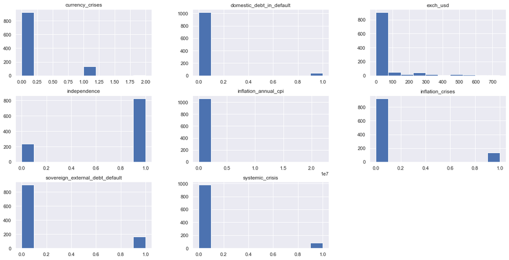

```python
crisis_2.hist()
plt.gcf().set_size_inches(20,10)
plt.show()
```

Del siguiente gráfico podemos observar como de "currency_crisis", "domestic_debt_in_default", y de "systematic_crisis" predomina el valor 0 frente al 1. En "exch_usd" se observa un descenso importante.

## 3. Outliers

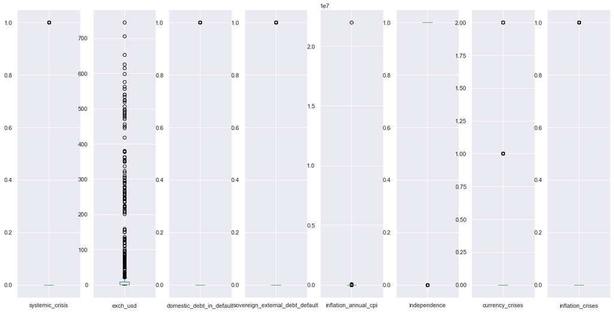

```python
crisis_2.plot(kind = 'box', subplots = True, sharex = False, sharey = False)
plt.gcf().set_size_inches(20,10)
plt.show()
```

En el siguiente gráfico podemos observar los valores atípicos

## 4. Dummies

Transformamos en dummies las variables categóricas y lo concatenamos con nuestro dataframe crisis_3, creando uno nuevo llamado crisis_new donde tan solo se han conservado las variables numéricas

```python
crisis_3=crisis.drop(['cc3','case','gdp_weighted_default','year'],axis=1)
crisis_3
```

|  | country | systemic_crisis | exch_usd | domestic_debt_in_default | sovereign_external_debt_default | inflation_annual_cpi | independence | currency_crises | inflation_crises | banking_crisis |
| --- | --- | --- | --- | --- | --- | --- | --- | --- | --- | --- |
| 0 | Algeria | 1 | 5.226400e-02 | 0 | 0 | 3.441456e+00 | 0 | 0 | 0 | crisis |
| 1 | Algeria | 0 | 5.279800e-02 | 0 | 0 | 1.414914e+01 | 0 | 0 | 0 | no_crisis |
| 2 | Algeria | 0 | 5.227400e-02 | 0 | 0 | -3.718593e+00 | 0 | 0 | 0 | no_crisis |
| 3 | Algeria | 0 | 5.168000e-02 | 0 | 0 | 1.120390e+01 | 0 | 0 | 0 | no_crisis |
| 4 | Algeria | 0 | 5.130800e-02 | 0 | 0 | -3.848561e+00 | 0 | 0 | 0 | no_crisis |
| 5 | Algeria | 0 | 5.154600e-02 | 0 | 0 | -2.092418e+01 | 0 | 0 | 0 | no_crisis |
| 6 | Algeria | 0 | 5.186700e-02 | 0 | 0 | -1.769547e+00 | 0 | 0 | 0 | no_crisis |
| 7 | Algeria | 0 | 5.186700e-02 | 0 | 0 | 2.911605e+01 | 0 | 0 | 1 | no_crisis |
| 8 | Algeria | 0 | 5.194800e-02 | 0 | 0 | -1.492537e+00 | 0 | 0 | 0 | no_crisis |
| 9 | Algeria | 0 | 5.202900e-02 | 0 | 0 | -1.683136e+01 | 0 | 0 | 0 | no_crisis |
| 10 | Algeria | 0 | 5.235600e-02 | 0 | 0 | 3.881188e+00 | 0 | 0 | 0 | no_crisis |
| 11 | Algeria | 0 | 5.202900e-02 | 0 | 0 | 1.261914e+01 | 0 | 0 | 0 | no_crisis |
| 12 | Algeria | 0 | 5.076100e-02 | 0 | 0 | -1.235613e+01 | 0 | 0 | 0 | no_crisis |
| 13 | Algeria | 0 | 5.200200e-02 | 0 | 0 | -1.390498e+00 | 0 | 0 | 0 | no_crisis |
| 14 | Algeria | 0 | 5.216500e-02 | 0 | 0 | -1.594203e+01 | 0 | 0 | 0 | no_crisis |
| 15 | Algeria | 0 | 4.490300e-01 | 0 | 0 | 9.756098e+00 | 0 | 0 | 0 | no_crisis |
| 16 | Algeria | 0 | 4.918900e-01 | 0 | 0 | 2.222222e+01 | 0 | 0 | 1 | no_crisis |
| 17 | Algeria | 0 | 4.493700e-01 | 0 | 0 | 1.636364e+01 | 0 | 0 | 0 | no_crisis |
| 18 | Algeria | 0 | 7.500000e-01 | 0 | 0 | 2.812500e+01 | 0 | 0 | 1 | no_crisis |
| 19 | Algeria | 0 | 5.000000e-01 | 0 | 0 | 4.634146e+01 | 0 | 1 | 1 | no_crisis |
| 20 | Algeria | 0 | 5.000000e-01 | 0 | 0 | 4.166667e+01 | 0 | 1 | 1 | no_crisis |
| 21 | Algeria | 0 | 1.191000e+00 | 0 | 0 | 2.941176e+01 | 0 | 0 | 1 | no_crisis |
| 22 | Algeria | 0 | 1.191000e+00 | 0 | 0 | 1.818182e+01 | 0 | 0 | 0 | no_crisis |
| 23 | Algeria | 0 | 1.193000e+00 | 0 | 0 | 6.923077e+01 | 0 | 0 | 1 | no_crisis |
| 24 | Algeria | 0 | 2.662000e+00 | 0 | 0 | 6.363636e+01 | 0 | 0 | 1 | no_crisis |
| 25 | Algeria | 0 | 3.490000e+00 | 0 | 0 | 2.361111e+01 | 0 | 0 | 1 | no_crisis |
| 26 | Algeria | 0 | 3.499000e+00 | 0 | 0 | 0.000000e+00 | 0 | 0 | 0 | no_crisis |
| 27 | Algeria | 0 | 3.500000e+00 | 0 | 0 | 6.741573e+00 | 0 | 0 | 0 | no_crisis |
| 28 | Algeria | 0 | 3.500000e+00 | 0 | 0 | 6.315789e+00 | 0 | 0 | 0 | no_crisis |
| 29 | Algeria | 0 | 3.500000e+00 | 0 | 0 | -9.900990e-01 | 0 | 0 | 0 | no_crisis |
| ... | ... | ... | ... | ... | ... | ... | ... | ... | ... | ... |
| 1029 | Zimbabwe | 0 | 1.450000e-26 | 0 | 0 | 2.030000e+01 | 1 | 1 | 1 | no_crisis |
| 1030 | Zimbabwe | 0 | 1.630000e-26 | 0 | 0 | 8.300000e+00 | 1 | 0 | 0 | no_crisis |
| 1031 | Zimbabwe | 0 | 1.680000e-26 | 0 | 0 | 1.450000e+01 | 1 | 0 | 0 | no_crisis |
| 1032 | Zimbabwe | 0 | 1.600000e-26 | 0 | 0 | 1.250000e+01 | 1 | 0 | 0 | no_crisis |
| 1033 | Zimbabwe | 0 | 1.930000e-26 | 0 | 0 | 7.400000e+00 | 1 | 1 | 0 | no_crisis |
| 1034 | Zimbabwe | 0 | 2.220000e-26 | 0 | 0 | 1.280000e+01 | 1 | 1 | 0 | no_crisis |
| 1035 | Zimbabwe | 0 | 2.610000e-26 | 0 | 0 | 1.740000e+01 | 1 | 1 | 0 | no_crisis |
| 1036 | Zimbabwe | 0 | 5.040000e-26 | 0 | 0 | 2.400000e+01 | 1 | 1 | 1 | no_crisis |
| 1037 | Zimbabwe | 0 | 5.370000e-26 | 0 | 0 | 4.160000e+01 | 1 | 0 | 1 | no_crisis |
| 1038 | Zimbabwe | 0 | 6.810000e-26 | 0 | 0 | 2.820000e+01 | 1 | 1 | 1 | no_crisis |
| 1039 | Zimbabwe | 0 | 8.380000e-26 | 0 | 0 | 2.111354e+01 | 1 | 1 | 1 | no_crisis |
| 1040 | Zimbabwe | 1 | 9.310000e-26 | 0 | 0 | 2.580874e+01 | 1 | 0 | 1 | crisis |
| 1041 | Zimbabwe | 1 | 1.080000e-25 | 0 | 0 | 1.640028e+01 | 1 | 1 | 0 | crisis |
| 1042 | Zimbabwe | 1 | 1.830000e-25 | 0 | 0 | 2.006504e+01 | 1 | 1 | 1 | crisis |
| 1043 | Zimbabwe | 1 | 3.710000e-25 | 0 | 0 | 4.661127e+01 | 1 | 1 | 1 | crisis |
| 1044 | Zimbabwe | 1 | 3.720000e-25 | 0 | 0 | 5.692320e+01 | 1 | 0 | 1 | crisis |
| 1045 | Zimbabwe | 1 | 5.500000e-25 | 1 | 1 | 5.520370e+01 | 1 | 1 | 1 | crisis |
| 1046 | Zimbabwe | 1 | 5.510000e-25 | 1 | 1 | 1.121184e+02 | 1 | 0 | 1 | crisis |
| 1047 | Zimbabwe | 1 | 5.500000e-25 | 1 | 1 | 1.989286e+02 | 1 | 0 | 1 | crisis |
| 1048 | Zimbabwe | 1 | 7.950000e-24 | 1 | 1 | 5.987448e+02 | 1 | 1 | 1 | crisis |
| 1049 | Zimbabwe | 1 | 5.600000e-23 | 1 | 1 | 1.327468e+02 | 1 | 1 | 1 | crisis |
| 1050 | Zimbabwe | 1 | 8.460000e-22 | 1 | 1 | 5.858444e+02 | 1 | 1 | 1 | crisis |
| 1051 | Zimbabwe | 1 | 3.000000e-19 | 1 | 1 | 1.281114e+03 | 1 | 1 | 1 | crisis |
| 1052 | Zimbabwe | 1 | 1.900000e-16 | 1 | 1 | 6.627989e+04 | 1 | 1 | 1 | crisis |
| 1053 | Zimbabwe | 1 | 2.000000e-03 | 1 | 1 | 2.198970e+07 | 1 | 1 | 1 | crisis |
| 1054 | Zimbabwe | 1 | 3.548000e+02 | 1 | 1 | -7.670000e+00 | 1 | 1 | 0 | crisis |
| 1055 | Zimbabwe | 0 | 3.782000e+02 | 1 | 1 | 3.217000e+00 | 1 | 0 | 0 | no_crisis |
| 1056 | Zimbabwe | 0 | 3.619000e+02 | 1 | 1 | 4.920000e+00 | 1 | 0 | 0 | no_crisis |
| 1057 | Zimbabwe | 0 | 3.619000e+02 | 1 | 1 | 3.720000e+00 | 1 | 0 | 0 | no_crisis |
| 1058 | Zimbabwe | 0 | 3.619000e+02 | 1 | 1 | 1.632000e+00 | 1 | 0 | 0 | no_crisis |

1059 rows × 10 columns

```python
dummies = pd.get_dummies(crisis_3)
dummies = dummies.drop(['exch_usd', 'inflation_annual_cpi'], axis = 1)
crisis_3 = crisis_3.drop(['country', 'systemic_crisis', 'domestic_debt_in_default', 'sovereign_external_debt_default', 'independence','currency_crises','inflation_crises','banking_crisis'], axis = 1)
crisis_new = pd.concat([crisis_3, dummies], axis=1)
```